# Data Transformation with dplyr & stringr + ggplot2 HW solution

Junqi Lu

# 1 Load data

```r
library('scRNAseq')
scRNAData <- scRNAseq #Because ggplot2 builder needs the dataset to be in the Environment
```

## 1.1 Preview data structure

```r
library('dplyr')
glimpse(scRNAData)
```

```
## Rows: 54,703
## Columns: 23
## $ gene_name                <chr> "WASH7P", "MIR6859-1", "MIR1302-2HG", "MIR130~
## $ gene_description         <chr> "WASP family homolog 7, pseudogene", "microRN~
## $ chromosome_scaffold_name <chr> "1", "1", "1", "1", "1", "1", "1", "1", "1", ~
## $ strand                   <int> -1, -1, 1, 1, -1, 1, 1, -1, -1, 1, -1, -1, -1~
## $ transcript_start_bp      <int> 14404, 17369, 29554, 30366, 34554, 52473, 654~
## $ transcript_end_bp        <int> 29570, 17436, 31097, 30503, 36081, 53312, 715~
## $ transcript_length        <int> 1351, 68, 712, 138, 1187, 840, 2618, 2748, 13~
## $ gene_percent_gc_content  <dbl> 54.43, 61.76, 48.84, 31.16, 50.26, 37.74, 32.~
## $ gene_type                <chr> "unprocessed_pseudogene", "miRNA", "lncRNA", ~
## $ tidybiology_score        <dbl> -0.61675495, 0.62248697, -0.41465915, -0.4989~
## $ gene_stable_id           <chr> "ENSG00000227232", "ENSG00000278267", "ENSG00~
## $ transcript_stable_id     <chr> "ENST00000488147", "ENST00000619216", "ENST00~
## $ organ                    <chr> "other", "other", "other", "other", "other", ~
## $ cell_1                   <int> 21, 15, 14, 24, 16, 21, 23, 17, 18, 16, 18, 2~
## $ cell_2                   <int> 19, 26, 20, 21, 24, 16, 28, 16, 9, 21, 24, 22~
## $ cell_3                   <int> 20, 7, 8, 22, 13, 20, 27, 28, 19, 13, 32, 28,~
## $ cell_4                   <int> 20, 22, 13, 23, 26, 20, 19, 22, 28, 10, 21, 1~
## $ cell_5                   <int> 17, 25, 19, 28, 18, 23, 29, 24, 21, 18, 16, 2~
## $ cell_6                   <int> 7, 20, 24, 18, 18, 23, 22, 17, 15, 19, 22, 13~
## $ cell_7                   <int> 23, 20, 19, 22, 14, 22, 22, 19, 18, 29, 16, 2~
## $ cell_8                   <int> 17, 16, 16, 13, 13, 22, 14, 24, 28, 25, 15, 1~
## $ cell_9                   <int> 23, 17, 18, 17, 21, 23, 29, 22, 26, 14, 16, 2~
## $ cell_10                  <int> 14, 16, 27, 19, 18, 20, 15, 23, 24, 18, 25, 2~
```

```r
head(scRNAData,4) #Dummy datasets will be generated from these 4 rows
```

|  | gene_name | gene_description | chromosome_scaffold_name | strand | transcript_start_bp | transcript_end_bp | transcript_length | gene_percent_gc_content | gene_type | tidybiology_score | gene_stable_id | transcript_stable_id | organ | cell_1 | cell_2 | cell_3 | cell_4 | cell_5 | cell_6 | cell_7 | cell_8 | cell_9 | cell_10 |
| --- | --- | --- | --- | --- | --- | --- | --- | --- | --- | --- | --- | --- | --- | --- | --- | --- | --- | --- | --- | --- | --- | --- | --- |
| 1 | WASH7P | WASP family homolog 7, pseudogene | 1 | -1 | 14404 | 29570 | 1351 | 54.43 | unprocessed_pseudogene | -0.6167549 | ENSG00000227232 | ENST00000488147 | other | 21 | 19 | 20 | 20 | 17 | 7 | 23 | 17 | 23 | 14 |
| 2 | MIR6859-1 | microRNA 6859-1 | 1 | -1 | 17369 | 17436 | 68 | 61.76 | miRNA | 0.6224870 | ENSG00000278267 | ENST00000619216 | other | 15 | 26 | 7 | 22 | 25 | 20 | 20 | 16 | 17 | 16 |
| 3 | MIR1302-2HG | MIR1302-2 host gene | 1 | 1 | 29554 | 31097 | 712 | 48.84 | lncRNA | -0.4146592 | ENSG00000243485 | ENST00000473358 | other | 14 | 20 | 8 | 13 | 19 | 24 | 19 | 16 | 18 | 27 |
| 4 | MIR1302-2 | microRNA 1302-2 | 1 | 1 | 30366 | 30503 | 138 | 31.16 | miRNA | -0.4989147 | ENSG00000284332 | ENST00000607096 | other | 24 | 21 | 22 | 23 | 28 | 18 | 22 | 13 | 17 | 19 |

# 2 Generate dummy df

```r
heart <- scRNAData[scRNAData$organ=='heart',]
brain <- scRNAData[scRNAData$organ=='brain',]
kidney <- scRNAData[scRNAData$organ=='kidney',]
```

# 3 Does the original df have any transcript appeared in more than 1 organ?

- Clue for more than 2 df join(): try to use %>%

```r
inner_join(heart, brain,by=c('gene_name'))
```

| gene_name | gene_description.x | chromosome_scaffold_name.x | strand.x | transcript_start_bp.x | transcript_end_bp.x | transcript_length.x | gene_percent_gc_content.x | gene_type.x | tidybiology_score.x | gene_stable_id.x | transcript_stable_id.x | organ.x | cell_1.x | cell_2.x | cell_3.x | cell_4.x | cell_5.x | cell_6.x | cell_7.x | cell_8.x | cell_9.x | cell_10.x | gene_description.y | chromosome_scaffold_name.y | strand.y | transcript_start_bp.y | transcript_end_bp.y | transcript_length.y | gene_percent_gc_content.y | … |
| --- | --- | --- | --- | --- | --- | --- | --- | --- | --- | --- | --- | --- | --- | --- | --- | --- | --- | --- | --- | --- | --- | --- | --- | --- | --- | --- | --- | --- | --- | --- |

```r
inner_join(heart, kidney,by=c('gene_name'))
```

| gene_name | gene_description.x | chromosome_scaffold_name.x | strand.x | transcript_start_bp.x | transcript_end_bp.x | transcript_length.x | gene_percent_gc_content.x | gene_type.x | tidybiology_score.x | gene_stable_id.x | transcript_stable_id.x | organ.x | cell_1.x | cell_2.x | cell_3.x | cell_4.x | cell_5.x | cell_6.x | cell_7.x | cell_8.x | cell_9.x | cell_10.x | gene_description.y | chromosome_scaffold_name.y | strand.y | transcript_start_bp.y | transcript_end_bp.y | transcript_length.y | gene_percent_gc_content.y | … |
| --- | --- | --- | --- | --- | --- | --- | --- | --- | --- | --- | --- | --- | --- | --- | --- | --- | --- | --- | --- | --- | --- | --- | --- | --- | --- | --- | --- | --- | --- | --- |

```r
inner_join(brain, kidney,by=c('gene_name'))
```

| gene_name | gene_description.x | chromosome_scaffold_name.x | strand.x | transcript_start_bp.x | transcript_end_bp.x | transcript_length.x | gene_percent_gc_content.x | gene_type.x | tidybiology_score.x | gene_stable_id.x | transcript_stable_id.x | organ.x | cell_1.x | cell_2.x | cell_3.x | cell_4.x | cell_5.x | cell_6.x | cell_7.x | cell_8.x | cell_9.x | cell_10.x | gene_description.y | chromosome_scaffold_name.y | strand.y | transcript_start_bp.y | transcript_end_bp.y | transcript_length.y | gene_percent_gc_content.y | … |
| --- | --- | --- | --- | --- | --- | --- | --- | --- | --- | --- | --- | --- | --- | --- | --- | --- | --- | --- | --- | --- | --- | --- | --- | --- | --- | --- | --- | --- | --- | --- |

```r
heart%>%
  inner_join(brain,by=c('gene_name')) %>%
  inner_join(kidney,by=c('gene_name'))
```

| gene_name | gene_description.x | chromosome_scaffold_name.x | strand.x | transcript_start_bp.x | transcript_end_bp.x | transcript_length.x | gene_percent_gc_content.x | gene_type.x | tidybiology_score.x | gene_stable_id.x | transcript_stable_id.x | organ.x | cell_1.x | cell_2.x | cell_3.x | cell_4.x | cell_5.x | cell_6.x | cell_7.x | cell_8.x | cell_9.x | cell_10.x | gene_description.y | chromosome_scaffold_name.y | strand.y | transcript_start_bp.y | transcript_end_bp.y | transcript_length.y | gene_percent_gc_content.y | … |
| --- | --- | --- | --- | --- | --- | --- | --- | --- | --- | --- | --- | --- | --- | --- | --- | --- | --- | --- | --- | --- | --- | --- | --- | --- | --- | --- | --- | --- | --- | --- |

# 4 Assembly the df from 3 organs together in a proper way and name the new df as three_organ_df

```r
three_organ_df <- heart %>%
  bind_rows(brain) %>%
  bind_rows(kidney)

three_organ_df
```

| gene_name | gene_description | chromosome_scaffold_name | strand | transcript_start_bp | transcript_end_bp | transcript_length | gene_percent_gc_content | gene_type | tidybiology_score | gene_stable_id | transcript_stable_id | organ | cell_1 | cell_2 | cell_3 | cell_4 | cell_5 | cell_6 | cell_7 | cell_8 | cell_9 | cell_10 |
| --- | --- | --- | --- | --- | --- | --- | --- | --- | --- | --- | --- | --- | --- | --- | --- | --- | --- | --- | --- | --- | --- | --- |
| NPPA | natriuretic peptide A | 1 | -1 | 11845709 | 11847783 | 855 | 54.04 | protein_coding | 1.939352606 | ENSG00000175206 | ENST00000376480 | heart | 84 | 12 | 17 | 107 | 15 | 15 | 21 | 22 | 116 | 23 |
| NPPB | natriuretic peptide B | 1 | -1 | 11857464 | 11858945 | 708 | 54.59 | protein_coding | -0.264414103 | ENSG00000120937 | ENST00000376468 | heart | 135 | 19 | 23 | 153 | 23 | 19 | 23 | 21 | 84 | 20 |
| HSPB7 | heat shock protein family B (small) member 7 | 1 | -1 | 16014028 | 16018041 | 2128 | 61.04 | protein_coding | -0.136897056 | ENSG00000173641 | ENST00000411503 | heart | 84 | 18 | 19 | 96 | 20 | 18 | 25 | 18 | 84 | 17 |
| MYOM3 | myomesin 3 | 1 | -1 | 24056035 | 24066579 | 2693 | 52.63 | protein_coding | 0.428949731 | ENSG00000142661 | ENST00000338909 | heart | 117 | 24 | 15 | 99 | 33 | 17 | 17 | 26 | 136 | 23 |
| TRIM63 | tripartite motif containing 63 | 1 | -1 | 26051304 | 26067633 | 1770 | 49.92 | protein_coding | 0.231450478 | ENSG00000158022 | ENST00000374272 | heart | 73 | 25 | 22 | 101 | 19 | 20 | 17 | 23 | 87 | 23 |
| FABP3 | fatty acid binding protein 3 | 1 | -1 | 31365253 | 31373076 | 1097 | 50.58 | protein_coding | -0.879550740 | ENSG00000121769 | ENST00000373713 | heart | 133 | 15 | 22 | 127 | 18 | 19 | 19 | 20 | 70 | 13 |
| GPX7 | glutathione peroxidase 7 | 1 | 1 | 52602371 | 52609051 | 1229 | 49.68 | protein_coding | -1.499010897 | ENSG00000116157 | ENST00000361314 | heart | 121 | 16 | 24 | 114 | 27 | 21 | 16 | 26 | 109 | 22 |
| CASQ2 | calsequestrin 2 | 1 | -1 | 115700007 | 115768781 | 2674 | 43.23 | protein_coding | 0.358814381 | ENSG00000118729 | ENST00000261448 | heart | 93 | 19 | 18 | 67 | 25 | 19 | 23 | 17 | 100 | 22 |
| S100A1 | S100 calcium binding protein A1 | 1 | 1 | 153627926 | 153632034 | 784 | 55.61 | protein_coding | 0.145325428 | ENSG00000160678 | ENST00000368698 | heart | 121 | 20 | 15 | 92 | 21 | 29 | 28 | 14 | 100 | 24 |
| PFDN2 | prefoldin subunit 2 | 1 | -1 | 161100556 | 161118055 | 408 | 44.06 | protein_coding | 1.320325189 | ENSG00000143256 | ENST00000468311 | heart | 119 | 26 | 19 | 64 | 11 | 26 | 17 | 17 | 89 | 21 |

[output cut: 290 more lines]

# 5 FIlter the genes from heart out from three_organ_df

- You can use either a join function or a negated %in% (**`%!in%` <- Negate(`%in%`)**)
- If you want to use a join function, make sure you understand which is the “left” and which is the “right”

```r
#Use anti_join()
anti_join(three_organ_df,heart,by=c('gene_name'))
```

| gene_name | gene_description | chromosome_scaffold_name | strand | transcript_start_bp | transcript_end_bp | transcript_length | gene_percent_gc_content | gene_type | tidybiology_score | gene_stable_id | transcript_stable_id | organ | cell_1 | cell_2 | cell_3 | cell_4 | cell_5 | cell_6 | cell_7 | cell_8 | cell_9 | cell_10 |
| --- | --- | --- | --- | --- | --- | --- | --- | --- | --- | --- | --- | --- | --- | --- | --- | --- | --- | --- | --- | --- | --- | --- |
| HPCAL4 | hippocalcin like 4 | 1 | -1 | 39678648 | 39691433 | 4600 | 52.50 | protein_coding | -0.591593495 | ENSG00000116983 | ENST00000372844 | brain | 24 | 22 | 114 | 21 | 103 | 14 | 15 | 16 | 18 | 98 |
| SV2A | synaptic vesicle glycoprotein 2A | 1 | -1 | 149903318 | 149917844 | 4378 | 52.16 | protein_coding | -2.099446591 | ENSG00000159164 | ENST00000369146 | brain | 16 | 21 | 92 | 11 | 132 | 17 | 24 | 16 | 20 | 88 |
| TRIM46 | tripartite motif containing 46 | 1 | 1 | 155173878 | 155180621 | 1864 | 57.80 | protein_coding | -0.025844698 | ENSG00000163462 | ENST00000368385 | brain | 16 | 23 | 96 | 23 | 85 | 16 | 16 | 20 | 19 | 75 |
| PAQR6 | progestin and adipoQ receptor family member 6 | 1 | -1 | 156243320 | 156248056 | 1969 | 60.94 | protein_coding | 0.934701557 | ENSG00000160781 | ENST00000292291 | brain | 27 | 20 | 96 | 17 | 112 | 14 | 11 | 20 | 19 | 100 |
| HAPLN2 | hyaluronan and proteoglycan link protein 2 | 1 | 1 | 156619415 | 156625725 | 1650 | 54.26 | protein_coding | -0.626433295 | ENSG00000132702 | ENST00000255039 | brain | 23 | 14 | 112 | 22 | 104 | 25 | 20 | 24 | 9 | 94 |
| BCAN | brevican | 1 | 1 | 156641390 | 156647144 | 600 | 55.82 | protein_coding | 0.373756660 | ENSG00000132692 | ENST00000441358 | brain | 17 | 18 | 66 | 18 | 101 | 23 | 16 | 14 | 18 | 87 |
| GPR37L1 | G protein-coupled receptor 37 like 1 | 1 | 1 | 202122917 | 202133592 | 6529 | 55.39 | protein_coding | 0.670643130 | ENSG00000170075 | ENST00000367282 | brain | 20 | 16 | 88 | 16 | 113 | 22 | 16 | 10 | 22 | 127 |
| ZNF488 | zinc finger protein 488 | 10 | -1 | 47365496 | 47384293 | 3516 | 49.61 | protein_coding | 0.485167606 | ENSG00000265763 | ENST00000585316 | brain | 26 | 22 | 93 | 20 | 82 | 14 | 19 | 25 | 18 | 131 |
| CEND1 | cell cycle exit and neuronal differentiation 1 | 11 | -1 | 787115 | 790090 | 1605 | 66.32 | protein_coding | -0.317205911 | ENSG00000184524 | ENST00000330106 | brain | 18 | 17 | 112 | 18 | 81 | 13 | 14 | 19 | 21 | 83 |
| PTPN5 | protein tyrosine phosphatase non-receptor type 5 | 11 | -1 | 18727928 | 18743842 | 2826 | 50.02 | protein_coding | 0.528923353 | ENSG00000110786 | ENST00000477854 | brain | 21 | 17 | 123 | 10 | 125 | 20 | 19 | 18 | 21 | 98 |

[output cut: 190 more lines]

```r
#Use %!in%
`%!in%` <- Negate(`%in%`)

three_organ_df %>%
  filter(gene_name %!in% heart[,'gene_name'])
```

| gene_name | gene_description | chromosome_scaffold_name | strand | transcript_start_bp | transcript_end_bp | transcript_length | gene_percent_gc_content | gene_type | tidybiology_score | gene_stable_id | transcript_stable_id | organ | cell_1 | cell_2 | cell_3 | cell_4 | cell_5 | cell_6 | cell_7 | cell_8 | cell_9 | cell_10 |
| --- | --- | --- | --- | --- | --- | --- | --- | --- | --- | --- | --- | --- | --- | --- | --- | --- | --- | --- | --- | --- | --- | --- |
| HPCAL4 | hippocalcin like 4 | 1 | -1 | 39678648 | 39691433 | 4600 | 52.50 | protein_coding | -0.591593495 | ENSG00000116983 | ENST00000372844 | brain | 24 | 22 | 114 | 21 | 103 | 14 | 15 | 16 | 18 | 98 |
| SV2A | synaptic vesicle glycoprotein 2A | 1 | -1 | 149903318 | 149917844 | 4378 | 52.16 | protein_coding | -2.099446591 | ENSG00000159164 | ENST00000369146 | brain | 16 | 21 | 92 | 11 | 132 | 17 | 24 | 16 | 20 | 88 |
| TRIM46 | tripartite motif containing 46 | 1 | 1 | 155173878 | 155180621 | 1864 | 57.80 | protein_coding | -0.025844698 | ENSG00000163462 | ENST00000368385 | brain | 16 | 23 | 96 | 23 | 85 | 16 | 16 | 20 | 19 | 75 |
| PAQR6 | progestin and adipoQ receptor family member 6 | 1 | -1 | 156243320 | 156248056 | 1969 | 60.94 | protein_coding | 0.934701557 | ENSG00000160781 | ENST00000292291 | brain | 27 | 20 | 96 | 17 | 112 | 14 | 11 | 20 | 19 | 100 |
| HAPLN2 | hyaluronan and proteoglycan link protein 2 | 1 | 1 | 156619415 | 156625725 | 1650 | 54.26 | protein_coding | -0.626433295 | ENSG00000132702 | ENST00000255039 | brain | 23 | 14 | 112 | 22 | 104 | 25 | 20 | 24 | 9 | 94 |
| BCAN | brevican | 1 | 1 | 156641390 | 156647144 | 600 | 55.82 | protein_coding | 0.373756660 | ENSG00000132692 | ENST00000441358 | brain | 17 | 18 | 66 | 18 | 101 | 23 | 16 | 14 | 18 | 87 |
| GPR37L1 | G protein-coupled receptor 37 like 1 | 1 | 1 | 202122917 | 202133592 | 6529 | 55.39 | protein_coding | 0.670643130 | ENSG00000170075 | ENST00000367282 | brain | 20 | 16 | 88 | 16 | 113 | 22 | 16 | 10 | 22 | 127 |
| ZNF488 | zinc finger protein 488 | 10 | -1 | 47365496 | 47384293 | 3516 | 49.61 | protein_coding | 0.485167606 | ENSG00000265763 | ENST00000585316 | brain | 26 | 22 | 93 | 20 | 82 | 14 | 19 | 25 | 18 | 131 |
| CEND1 | cell cycle exit and neuronal differentiation 1 | 11 | -1 | 787115 | 790090 | 1605 | 66.32 | protein_coding | -0.317205911 | ENSG00000184524 | ENST00000330106 | brain | 18 | 17 | 112 | 18 | 81 | 13 | 14 | 19 | 21 | 83 |
| PTPN5 | protein tyrosine phosphatase non-receptor type 5 | 11 | -1 | 18727928 | 18743842 | 2826 | 50.02 | protein_coding | 0.528923353 | ENSG00000110786 | ENST00000477854 | brain | 21 | 17 | 123 | 10 | 125 | 20 | 19 | 18 | 21 | 98 |

[output cut: 190 more lines]

# 6 Conditional coloring in ggplot by stringr pattern detect

## 6.1 What gene types do you have in scRNAData?

```r
sort(table(scRNAData$gene_type), decreasing = TRUE)
```

```
##
##         protein_coding                 lncRNA   processed_pseudogene
##                  20202                  17487                  10418
## unprocessed_pseudogene                  miRNA                  snRNA
##                   2889                   1878                   1829
```

## 6.2 What is the average transcript lengthn for non-pseudogenes from brain? Make a plot to answer this.

Additional requirements:

- Filter the scRNAData by transcript length by a range that you think is reasonable to remove potential artifacts
- Change the x-axis label of a boxplot to **Pseudogenes** if its gene type belongs to pseudogenes or **Non-pseudogenes** if not
- Use the organ label to fill in the color of boxplots. If a gene is from brain, label it as **Brain-related**; if not from brain, label it as **Other-organs-related**

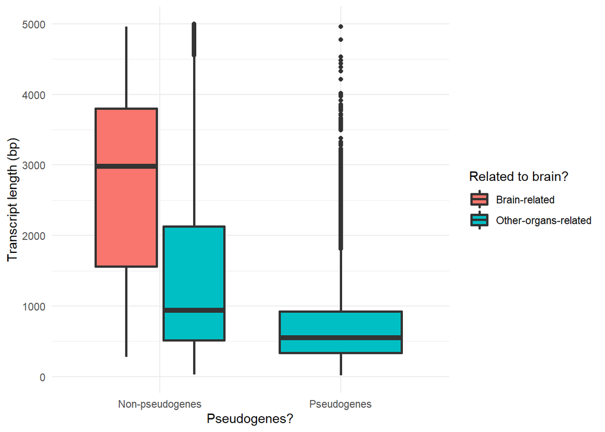

```r
library(ggplot2)
library(stringr)

filtered_df <- scRNAData[scRNAData$transcript_length < 5000,]

ggplot(filtered_df) +
  aes(
    x = ifelse(
      str_detect(gene_type, 'pseudogene$'),
      'Pseudogenes',
      'Non-pseudogenes'),
    y = transcript_length,
    fill = ifelse(organ == 'brain', 'Brain-related', 'Other-organs-related')

  ) +
  geom_boxplot(size = 1,) +


  labs(x='Pseudogenes?',
       y='Transcript length (bp)',
       fill = 'Related to brain?') +
  theme_minimal()
```